# QML tutorial - Week 5

## 1 Emotional valence of sense words

We will model data from Winter, 2016. *Taste and smell words form an affectively loaded part of the English lexicon*. DOI: 10.1080/23273798.2016.1193619. The study looked at the emotional valence of sense words in English, in the domains of taste and smell.

To download the file with the data right-click on the following link and download the file: senses_valence.csv. (Note that tutorial files are also linked in Course content). Remember to save the file in `data/` in the course project folder.

Create a new `.Rmd` file first, save it in `code/` and name it `tutorial-w05` (the extension `.Rmd` is added automatically!).

I leave to you creating title headings in your file as you please. Remember to to add `knitr::opts_knit$set(root.dir = here::here())` in the `setup` chunk and to attach the tidyverse.

Let’s read the data. The original data also include words from other senses, so for this tutorial we will filter the data to include only the following `Modality`: `Smell` and `Taste` words. Complete the code below to filter the data.

```r
senses_valence <- read_csv("data/senses_valence.csv") %>%
  filter(
    ...
  )
```

This is what the data frame looks like.

```r
senses_valence
```

| Word | Modality | Val |
| --- | --- | --- |
| acidic | Taste | 5.539592 |
| acrid | Smell | 5.173947 |
| alcoholic | Taste | 5.557228 |
| antiseptic | Smell | 5.511795 |
| aromatic | Smell | 5.952941 |
| astringent | Taste | 5.965000 |
| barbecued | Taste | 6.052778 |
| beery | Taste | 6.072143 |
| bitter | Taste | 5.124433 |
| bland | Taste | 5.752286 |

[output cut: 62 more lines]

There are three columns:

- `Word`: the English word [categorical].
- `Modality`: `Taste` or `Smell` [categorical].
- `Val`: emotional valence [numeric, continuous]. The higher the number the more positive the valence.

Let’s quickly check the minimum and maximum values in `Val`. Do you remember which function returns those two?

```r
...(senses_valence$Val)
```

```
[1] 4.630476 6.436000
```

This is what the density plot of `Val` looks like.

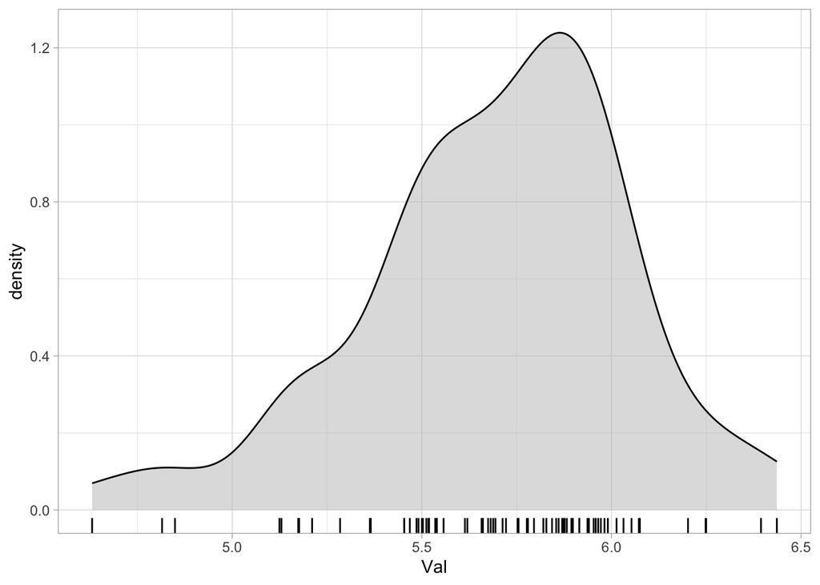

```r
senses_valence %>%
  ggplot(aes(Val)) +
  geom_density(fill = "gray", alpha = 0.5) +
  geom_rug()
```

And if we separate by `Modality`, we can see that the density of taste words is shifted towards higher values than that of smell words. Try to reproduce the following plot in your code.

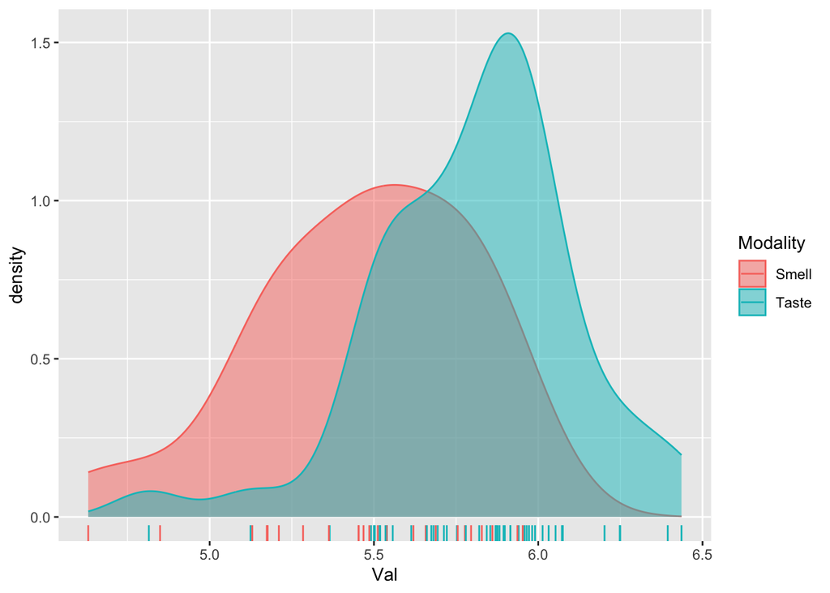

**Hint**

Make sure that `fill` and `colour` are within `aes()`.

If you were asked to write a description of the data, you could write the following:

> The data contains 72 observations of the emotional valence of taste (N = 47) and smell (N = 25) words. The range of emotional valence is 1.8 (min = 4.6, max = 6.4). The median valence for taste words is 5.9 (SD = 0.3) while the median valence for smell words is 5.5 (SD = 0.3). As shown in the plot, in this sample of 72 words, taste words are generally associated with a somewhat higher emotional valence than smell words.

### 1.1 Modelling emotional valence

Now that we got an overview of what the data looks like, let’s move onto modelling it with `brm()`!

Let’s assume, as we did with the VOT values, that the emotional valence values come from a Gaussian distribution.[^1] In notation:

$$\text{val} \sim Gaussian(\mu, \sigma)$$

Now, we want to estimate $\mu$ so that we take into consideration whether the modality is “smell” or “taste”. In other words, we want to model valence as a function of modality, in R code `Val ~ Modality`.

`Modality` is a categorical variable (a `chr` character column in `sense_valence`) so it is coded using the default treatment coding system (this is done under the hood by R for you!). Since `Modality` has 2 levels, R will create for us a N-1 = 1 dummy variable (for illustration, we can imagine that it’s called `modality_taste`).

This is what the coding would look like:

|  | modality_taste |
| --- | --- |
| modality = smell | 0 |
| modality = taste | 1 |

**Warning**

R assigns the reference level, i.e., 0, to “smell”, because “s” comes before “t” in the alphabet.

Now we allow $\mu$ to vary depending on modality.

$$\mu = \beta_0 + \beta_1 \cdot modality_{Taste}$$

**Formula of a line**

You might recognise the form of this equation from school, where you probably saw the formula for a line:

$$y = b + m \cdot x$$

where $b$ is the **intercept**, and $m$ is the **slope**. Exact same thing here! That’s why it’s called a *linear* model or *linear* regression).

You can play with this web app to learn what the intercept and slope do: https://stefanocoretta.shinyapps.io/lines/

Let’s unpack the equation. There’s a bit of algebra in what follows, so take your time if this is a bit out of your comfort zone. But it’s worth it—familiarity with basic algebra will also help you become more comfortable working with linear models.

- $\beta_0$ is the **mean valence** $\mu$ when [modality = smell]. That’s because the variable $modality_{Taste}$ takes on the value 0 when [modality = smell] (as we can see from the table above). Multiplying by 0 means that $\beta_1$ vanishes from the equation, and all that’s left is $\beta_0$.

$$\begin{aligned}
\mu &= \beta_0 + \beta_1 \cdot modality_{Taste}\\
\mu_{mod = smell} &= \beta_0 + \beta_1 \cdot 0 \\
\mu_{mod = smell} &= \beta_0 \\
\end{aligned}$$

- $\beta_1$ is the **difference in mean valence** $\mu$ between the mean valence when [modality = taste] and the mean valence when [modality = smell]. That’s because $modality_{Taste}$ takes on the value 1 when [modality = taste], and multiplying $\beta_1$ by 1 leaves it unchanged in the equation.

$$\begin{aligned}
\mu &= \beta_0 + \beta_1 \cdot modality_{Taste}\\
\mu_{mod = taste} &= \beta_0 + \beta_1 \cdot 1 \\
\mu_{mod = taste} &= \beta_0 + \beta_1 \\
\end{aligned}$$

- How do we know that $\beta_1$ really represents the difference between the mean valence when [modality = smell] and the mean valence when [modality = taste]? Remember that $\mu_{mod = smell} = \beta_0$, as we said in the first point above. We can substitute this into the equation from the last point, and then isolate $\beta_1$ step by step as follows:

$$\begin{aligned}
\beta_0 & = \mu_{mod=smell} \\
\mu_{mod = taste} &= \beta_0 + \beta_1 \\
\mu_{mod = taste} &= \mu_{mod=smell} + \beta_1 \\
\mu_{mod = taste} - \mu_{mod=smell} &= \mu_{mod=smell} + \beta_1 - \mu_{mod=smell} \\
\mu_{mod = taste} - \mu_{mod=smell} &= \beta_1
\end{aligned}$$

So, $\beta_1$ really is the difference between the means of these two levels of `Modality`.

Now we can define the probability distributions of $\beta_0$ and $\beta_1$.

$$\begin{align}
\beta_0 & \sim Gaussian(\mu_0, \sigma_0) \\
\beta_1 & \sim Gaussian(\mu_1, \sigma_1)
\end{align}$$

And the usual for $\sigma$.

$$\sigma \sim TruncGaussian(\mu_2, \sigma_2)$$

Here’s the full mathematical specification of the model.

$$\begin{align}
\text{val} & \sim Gaussian(\mu, \sigma) \\
\mu & = \beta_0 + \beta_1 \cdot modality_{Taste} \\
\beta_0 & \sim Gaussian(\mu_0, \sigma_0) \\
\beta_1 & \sim Gaussian(\mu_1, \sigma_1) \\
\sigma & \sim TruncGaussian(\mu_2, \sigma_2)
\end{align}$$

**Quiz 1**

Since smell words have a lower emotional value than taste words, will $\beta_1$ be:

Positive. 0. Negative.

**Hint**

Be careful: $\beta_1$ is the difference between taste and smell words (`taste - smell`), rather than the difference between smell and taste words (`smell - taste`).

### 1.2 Run the model

Now we know what the model will do, we can run it.

Before that though, create a folder called `cache/` in the `data/` folder of the RStudio project of the course. We will use this folder to save the output of model fitting so that you don’t have to refit the model every time. (This is useful because as models get more and more complex, they can take quite a while to fit.)

After you have created the folder, run the following code.

```r
val_bm <- brm(
  Val ~ Modality,
  family = gaussian(),
  data = senses_valence,
  backend = "cmdstanr",
  # Save model output to file
  file = "data/cache/val_bm"
)
```

The model will be fitted and saved in `data/cache/` with the file name `val_bm.rds`. If you now re-run the same code again, you will notice that `brm()` does not fit the model again, but rather reads it from the file (no output is shown, but trust me, it works! Check the contents of `data/cache/` to see for yourself.).

**Warning**

When you save the model fit to a file, R does not keep track of changes in the model specification, so if you make changes to the formula or data, you need to **delete the saved model file** before re-running the code for the changes to have effect!

When reporting the model specification, you can write the following:

> We fitted a Bayesian model with emotional valency as the outcome variable and modality (smell vs taste) as the only predictor. A Gaussian family was used as the outcome distribution family. The modality predictor was coded with the default treatment contrasts (with “smell” as the reference level).

### 1.3 Interpret the model output

Let’s inspect the model summary.

```r
summary(val_bm)
```

```
 Family: gaussian
  Links: mu = identity; sigma = identity
Formula: Val ~ Modality
   Data: senses_valence (Number of observations: 72)
  Draws: 4 chains, each with iter = 2000; warmup = 1000; thin = 1;
         total post-warmup draws = 4000

Population-Level Effects:
              Estimate Est.Error l-95% CI u-95% CI Rhat Bulk_ESS Tail_ESS
Intercept         5.47      0.06     5.35     5.59 1.00     3800     3149
ModalityTaste     0.34      0.08     0.18     0.50 1.00     3866     2984

Family Specific Parameters:
      Estimate Est.Error l-95% CI u-95% CI Rhat Bulk_ESS Tail_ESS
sigma     0.32      0.03     0.27     0.38 1.00     3136     2573

Draws were sampled using sample(hmc). For each parameter, Bulk_ESS
and Tail_ESS are effective sample size measures, and Rhat is the potential
scale reduction factor on split chains (at convergence, Rhat = 1).
```

Model summaries have three main parts:

- Information on the model, like family, formula and data.
- Population-level effects, with estimates of the intercept and any predictor’s coefficient.
- Family specific parameters, with `sigma` when using a Gaussian family.

Look at the `Population-Level Effects` part of the summary.

```
Population-Level Effects:
              Estimate Est.Error l-95% CI u-95% CI Rhat Bulk_ESS Tail_ESS
Intercept         5.47      0.06     5.35     5.59 1.00     3800     3149
ModalityTaste     0.34      0.08     0.18     0.50 1.00     3866     2984
```

We get two **coefficients**:

- `Intercept`: this is our $\beta_0$.
- `ModalityTaste`: this is our $\beta_1$.

Each coefficient has an `Estimate` and an `Est.Error` (estimate error). As we have seen last week, these are the **mean and SD of the probability distribution** of the coefficients.

In notation:

$$\begin{align}
\mu & = \beta_0 + \beta_1 \cdot modality_{Taste} \\
\beta_0 & \sim Gaussian(5.47, 0.06) \\
\beta_1 & \sim Gaussian(0.34, 0.08)
\end{align}$$

This means that:

- The **probability distribution of the mean valence when [modality = smell]** is a Gaussian distribution with mean = 5.47 and SD = 0.06.
- The **probability distribution of the difference** between the mean valence of [modality = taste] and that of [modality = smell] is a Gaussian distribution with mean = 0.34 and SD = 0.08.

**Quiz 2**

**What is the mean valency for taste words?**

**Hint**

Just use the formula of $\mu$ and replace the $\beta$ coefficients with the mean of the respective distributions.

Now let’s look at the **Credible Intervals** (CrIs, or CI in the model summary) of the coefficients. Based on the reported 95% CrIs, we can say that:

- We can be 95% confident that (you can also say, “there is a 95% probability that”), based on the data and the model, the mean emotional valence of smell words is between 5.35 and 5.59.
- There is a 95% probability that the difference in mean emotional valence between taste and smell words is between 0.18 and 0.5. In other words, the emotional valence increases by 0.18 to 0.5 in taste words relative to smell words.

You could report these results in the following way:

> According to the model, the mean valency of smell words is 5.47 (SD = 0.06), with a 95% probability that it is between 5.35 and 5.59. At 95% confidence, the difference in valency between taste and smell words is between 0.18 and 0.5 ($\beta$ = 0.34, SD = 0.08).

**But what about the probability distribution of the valence of taste words?**

For that we need to do a bit of data wrangling, but before we get there we need to talk about posterior probability distributions and posterior draws.

## 2 Posteriors

**Posterior probability distribution**

The probability distributions of model coefficients obtained through model fitting with `brm()` are called **posterior probability distributions**.

Note that you can abbreviate the phrase “posterior probability distribution” to *posterior probability* or just *posterior*, but remember we are talking about probability distributions.

They are called **posterior** probabilities because they are the product of the evidence from the data and any *prior* probability distribution. A prior probability distribution is a probability distribution that conveys the prior beliefs of the researcher in regards to the model coefficients.

We will not further talk about priors in this course, but for now, just know that we are using the default priors used by `brm()`: these priors are basically equivalent to saying “I have no prior believes about the model coefficients, so I will let the data speak for themselves”.

If you are interested in learning a bit more about priors, check the “Extra” box below.

**But how are these posterior probabilities constructed, you might ask?**

The answer is: through the MCMC algorithm! (If you need a refresher on what MCMC is, check the tutorial from Week 4).

**Extra: Priors**

### 2.1 Posterior draws

In order to estimate the coefficients, `brm()` runs a number of MCMC iterations and at each iteration a value for each coefficient in the model is proposed (this is a simplification, if you want to know more about the inner working of MCMCs, check the *Statistical (Re)Thinking* book).

At the end, what you get is a list of values for each coefficient in the model. These are called the **posterior draws**. The probability distribution of the posterior draws of a coefficient is the posterior probability distribution of that coefficient.

**Posterior draws**

The **posterior draws** are the list of coefficient values returned by the MCMC sampling procedure.

If you take the mean and standard deviation of the posterior draws of a coefficient, you get the `Estimate` and `Est.Error` values in the model output! Let’s try this.

You can easily extract the posterior draws of all the model’s coefficients with the `as_draws_df()` function from the brms package.

```r
val_bm_draws <- as_draws_df(val_bm)
val_bm_draws
```

| b_Intercept | b_ModalityTaste | sigma | lprior | lp__ | .chain | .iteration | .draw |
| --- | --- | --- | --- | --- | --- | --- | --- |
| 5.40516 | 0.4009020 | 0.326524 | -3.15267 | -22.8960 | 1 | 1 | 1 |
| 5.52508 | 0.2557150 | 0.306671 | -3.15123 | -22.8559 | 1 | 2 | 2 |
| 5.45323 | 0.3664490 | 0.305962 | -3.15118 | -22.3633 | 1 | 3 | 3 |
| 5.49178 | 0.3152610 | 0.294962 | -3.15047 | -22.5650 | 1 | 4 | 4 |
| 5.50677 | 0.3597910 | 0.325888 | -3.15269 | -23.2816 | 1 | 5 | 5 |
| 5.51062 | 0.3347060 | 0.313217 | -3.15174 | -22.7867 | 1 | 6 | 6 |
| 5.51062 | 0.3347060 | 0.313217 | -3.15174 | -22.7867 | 1 | 7 | 7 |
| 5.46277 | 0.3105710 | 0.308737 | -3.15148 | -22.5730 | 1 | 8 | 8 |
| 5.44241 | 0.3787590 | 0.311971 | -3.15158 | -22.4012 | 1 | 9 | 9 |
| 5.36180 | 0.4315470 | 0.321137 | -3.15252 | -23.8018 | 1 | 10 | 10 |

[output cut: 3990 more lines]

Check the first three columns of the tibble (don’t worry about the other columns—those are technical things that are important for brms, but not so important for us). The first three columns are our $\beta_0$, $\beta_1$ and $\sigma$ from the model formulae above!

- `b_Intercept`: $\beta_0$.
- `b_ModalityTaste`: $\beta_1$.
- `sigma`: $\sigma$.

(Why is there a `b` at the beginning of `b_Intercept` and `b_ModalityTaste`? Well, “b” is for “beta”, and it’s brms’s way of telling us what kind of coefficient we’re working with.)

Now go ahead and use `summarise()` (careful, not the `summary()` function) to get the mean and standard deviation of the posteriors of the three coefficients.

```r
val_bm_draws %>%
  summarise(
    ...
  )
```

**Extra: Summarise with `across()`**

To get the mean and SD of the three coefficients, you probably added individual lines of code for each coefficient and summary measure inside `summarise()`.

That is perfectly valid, but there is also an advanced, more succinct way of achieving the same result. Open the this Code box to reveal it!

**Code**

```r
val_bm_draws %>%
  select(b_Intercept:sigma) %>%
  summarise(
    across(everything(), list("mean" = mean, "sd" = sd))
  )
```

| b_Intercept_mean | b_Intercept_sd | b_ModalityTaste_mean | b_ModalityTaste_sd | sigma_mean | sigma_sd |
| --- | --- | --- | --- | --- | --- |
| 5.472048 | 0.06455602 | 0.3372408 | 0.08031468 | 0.320456 | 0.02758145 |

Now that we have the posterior draws in `val_bm_draws`, we can simply use ggplot2 to plot the probability density of the draws, a.k.a., the posterior probability distribution, for each coefficient.

## 3 Plotting probability distributions

They say a plot is better than a thousand words, so why don’t we plot the probability distributions of the `Intercept` ($\beta_0$) and `ModalityTaste` ($\beta_1$) coefficients?

There are different methods for plotting these, each of which has its own advantages and disadvantages. Some methods require extra packages, while others work with the packages you already know of.

To simplify things, we will use a method that works out of the box using just ggplot2.

Let’s start with the posterior probability, or *posterior* for short, of `b_Intercept`.

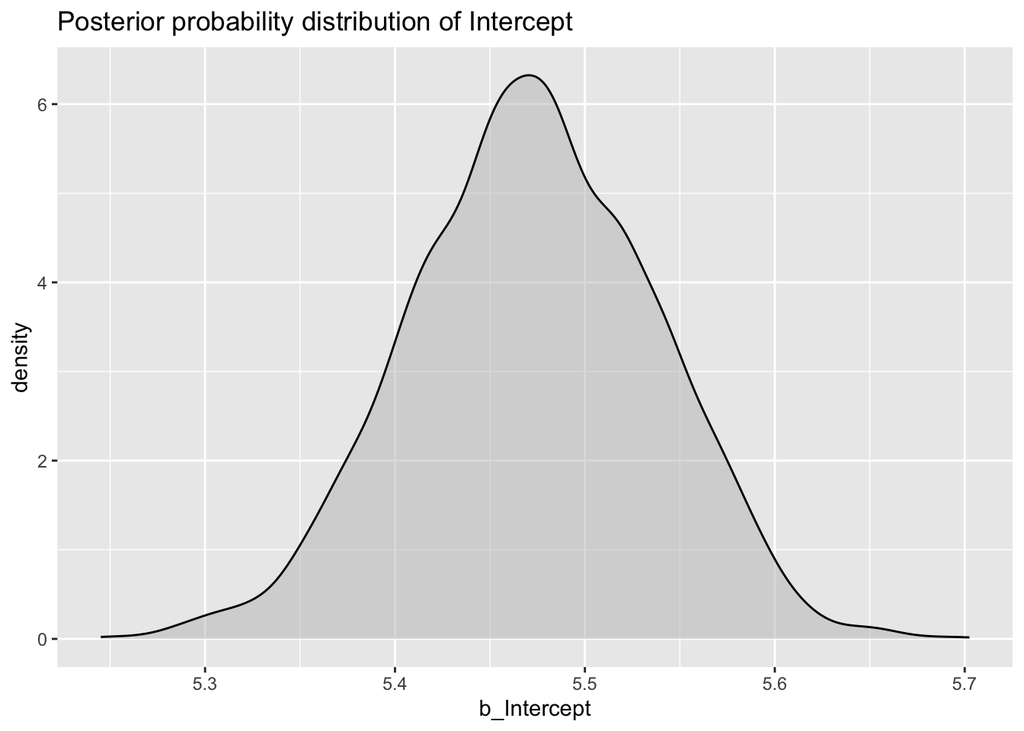

```r
val_bm_draws %>%
  ggplot(aes(b_Intercept)) +
  geom_density(fill = "gray", alpha = 0.5) +
  labs(
    title = "Posterior probability distribution of Intercept"
  )
```

Nice, huh?

Now with `b_ModalityTaste`. We can add a vertical line that shows the mean using `geom_vline()`.

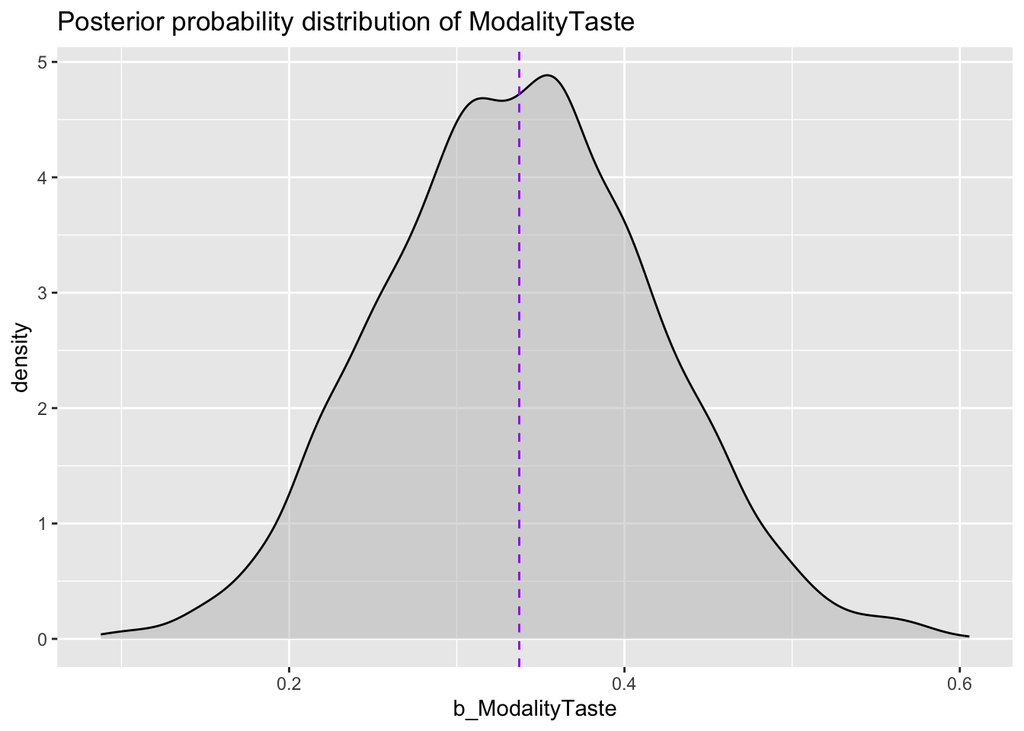

```r
taste_mean <- mean(val_bm_draws$b_ModalityTaste)

val_bm_draws %>%
  ggplot(aes(b_ModalityTaste)) +
  geom_density(fill = "gray", alpha = 0.5) +
  geom_vline(xintercept = taste_mean, linetype = "dashed", colour = "purple") +
  labs(
    title = "Posterior probability distribution of ModalityTaste"
  )
```

Now recreate the following plot, which shows the posterior distribution of `sigma`.

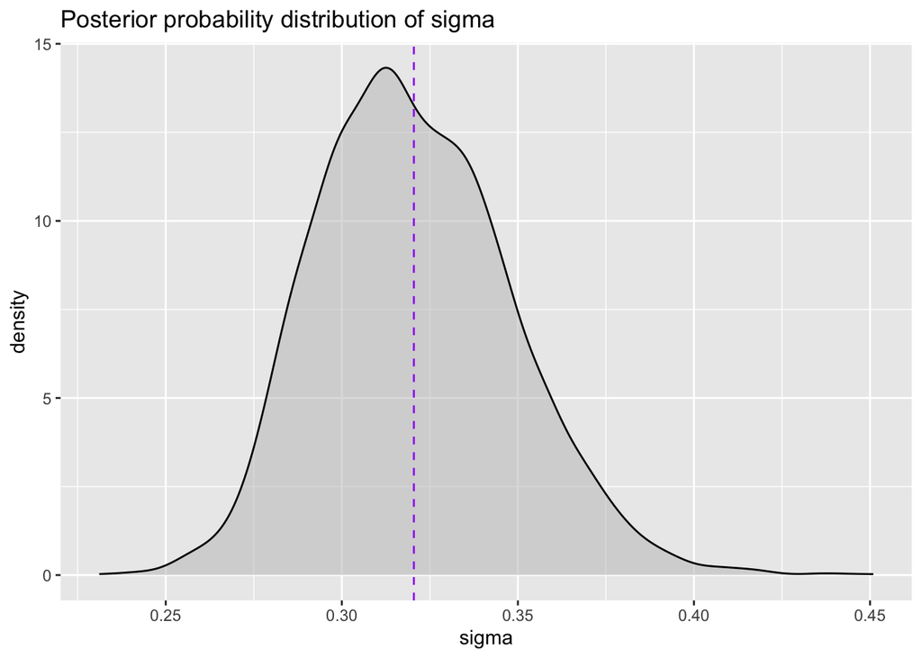

## 4 Conditional probability distributions

This is all great, but what if you wanted to know the probability distribution of mean emotional valence in either smell or taste words? So far, we only know the probability distribution of mean valence for smell words ($\beta_0$), and *how that valence is changed* for taste words ($\beta_1$). We don’t yet know the probability distribution of mean emotional valence for taste words. How do we find that distribution?

This is where **conditional posterior probability distributions** (or conditional probabilities for short) come in!

They are posterior probability distributions like the ones we have plotted above, but they are **conditional** on specific values of each predictor in the model.

In the `val_bm` model we had only included one predictor (we will see how to include more in the coming weeks): `Modality`, which has two levels `Smell` and `Taste`.

How do we obtain the conditional probabilities of emotional valence for smell and taste words respectively?

The formula of $\mu$ above can help us solve the mystery.

$$\mu = \beta_0 + \beta_1 \cdot modality_{Taste}$$

The conditional probability of mean emotional valence in smell words is just $\beta_0$. Why? Remember that when [modality = smell], $modality_{Taste}$ is 0, so:

$$\beta_0 + \beta_1 \cdot 0 = \beta_0$$

In other words, the conditional probability of mean emotional valence in smell words is equal to the posterior probability of `b_Intercept`. This is so because `Modality` is coded using the treatment coding system (nothing mysterious here).

But what about taste words? Here’s where we need to do some more maths/data processing.

When [modality = taste], $modality_{Taste}$ is 1, so:

$$\beta_0 + \beta_1 \cdot 1 = \beta_0 + \beta_1$$

So to get the *conditional posterior probability* of mean emotional valence for taste words, we need to **sum the posterior draws** of `b_Intercept` ($\beta_0$) and `b_ModalityTaste` ($\beta_1$): $\beta_0 + \beta_1$.

It couldn’t be easier than using the `mutate()` function from dplyr. Remember that `mutate()` creates a new column (here, called `taste`) based on the values of other columns. Here, we’re just adding together the values in `b_Intercept` and those in `b_ModalityTaste` (a.k.a., the posterior draws for each of those coefficients).

```r
val_bm_draws <- val_bm_draws %>%
  mutate(
    taste = b_Intercept + b_ModalityTaste
  )
```

Now, we can just plot the probability density of `taste` to get the conditional posterior probability distribution of mean emotional valence for taste words.

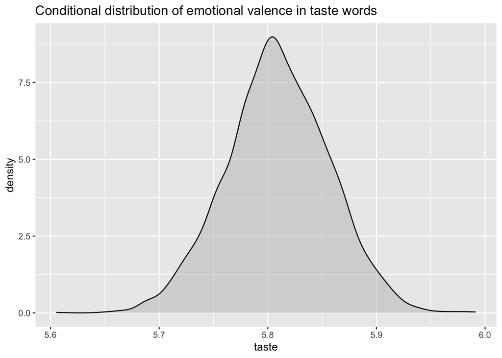

```r
val_bm_draws %>%
  ggplot(aes(taste)) +
  geom_density(fill = "gray", alpha = 0.5) +
  labs(
    title = "Conditional distribution of emotional valence in taste words"
  )
```

What if you want to show both the conditional probability of emotional valence in smell and taste words? Easy![^2]

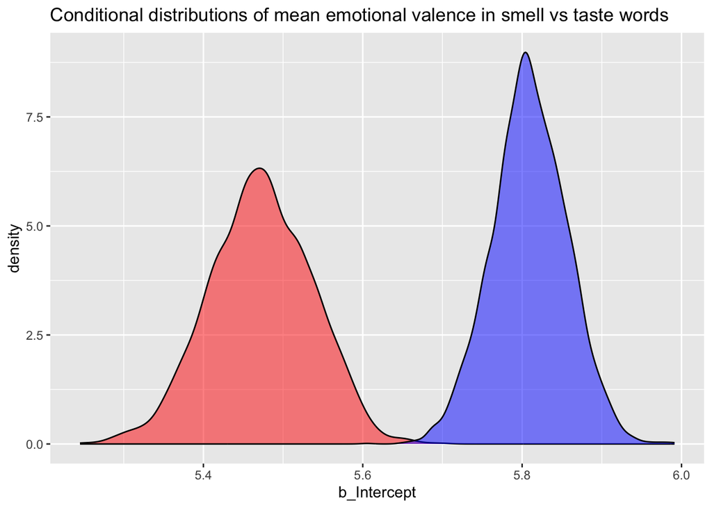

```r
val_bm_draws %>%
  ggplot() +
  geom_density(aes(b_Intercept), fill = "red", alpha = 0.5) +
  geom_density(aes(taste), fill = "blue", alpha = 0.5) +
  labs(
    title = "Conditional distributions of mean emotional valence in smell vs taste words"
  )
```

Based on this plot, we can say that the model suggests a different mean emotional valence for smell vs. taste words, and that taste words (blue) have a more positive emotional valence than smell words (red).

To reiterate from above, based on the 95% CrI of `b_ModalityTaste`, there is a 95% probability that the mean emotional valence of taste words is 0.18 to 0.5 greater than that of smell words.

You might ask now: *Is this difference relevant?* Unfortunately, statistics cannot help you to answer that question (remember, *we* imbue numbers with meaning). Only conceptual theories of lexical emotional valence can (or cannot)!